# OSKT: Normalization via Optimized Skewness and Kurtosis

Zeynel Cebeci

2026-2-2

# 1 Introduction

The Normality Transformation via Optimized Skewness and Kurtosis (OKST) is a normality method that simultaneously evaluates deviations in skewness and kurtosis of non-normal data.

# 2 Required Packages

The recent version of the package `osktnorm` from CRAN is installed with the following command:

```r
install.packages("osktnorm", repos="https://cloud.r-project.org", dep=TRUE)
```

If the package `osktnorm` has already been installed, load it into R working environment by using the following command:

```r
library(osktnorm)
```

# 3 Normality Transformation Using OSKT

In the following code snippet, a right-skewed distribution with 300 observations is generated using `rlnorm` of R and then normalized using OSKT. For this purpose, the `okstfast` function is applied by simply passing the original observation vector to be transformed, and the results are stored in the object `res_okst`.

In this result object `res_okst`, the transformed values are contained in the `transformed` vector. The element `g` contains the skewness parameter used in the transformation, which is obtained via optimization L-BFGS, while `h` contains the kurtosis parameter. In the output, `value` indicates the minimum `A2` value reached during optimization, i.e., the Anderson–Darling statistic at the optimum..

```r
set.seed(12)
x_orig <- rlnorm(300, mean=0, sd=0.5) # Generate right-skewed data

# Apply OSKT normality
res_oskt <- osktfast(x_orig)

x_transformed <- res_oskt$transformed
head(x_transformed, 5)
  [1] -1.802405  1.399281 -1.250515 -1.210836 -2.307431

g_star <- res_oskt$g
h_star <- res_oskt$h
A2 <- res_oskt$value

cat("Optimized skewness: ", g_star, "\n")
  Optimized skewness:  -0.5909241
cat("Optimized kurtosis: ", h_star, "\n")
  Optimized kurtosis:  0.07987875
cat("Anderson-Darling statistic at the optimum: ", A2, "\n")
  Anderson-Darling statistic at the optimum:  0.1056021
```

The code snippet below visualizes the original and normalized observations using histograms and density plots for comparison purposes. To ensure a fair comparison, 25 common breaks are set for both histograms. Upon examining the plots, it is evident that the data transformed via OSKT (red) approximates the normal distribution (black dashed line).

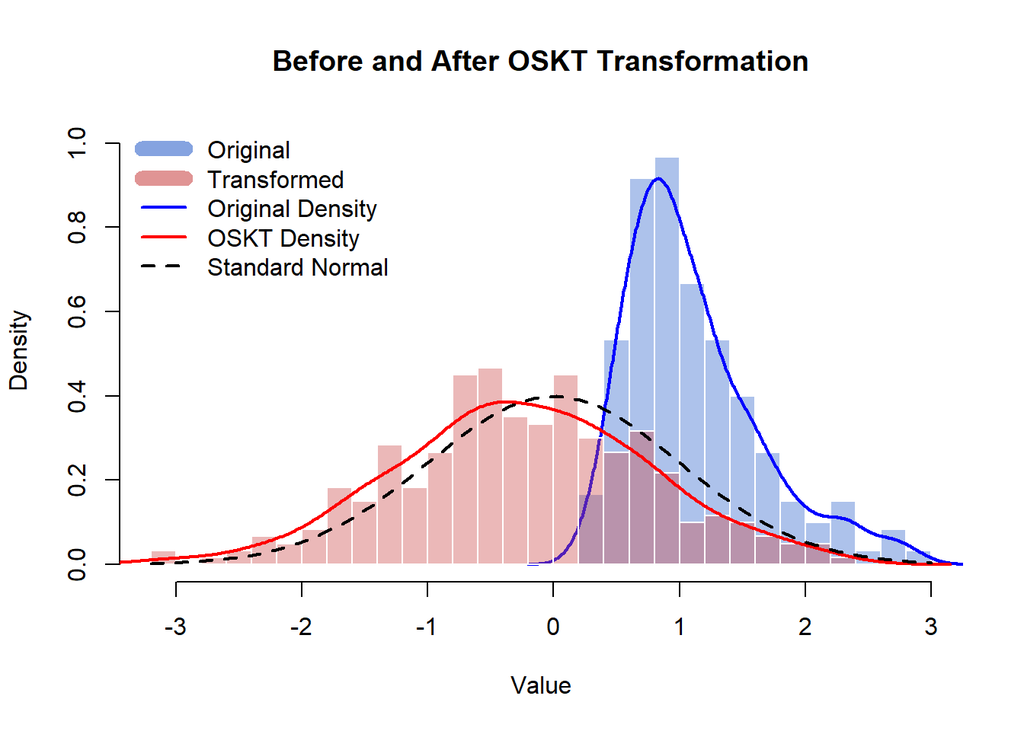

```r
breaks <- pretty(range(c(x_orig, x_transformed)), n = 25)
h_orig  <- hist(x_orig, breaks = breaks, plot = FALSE)
h_trans <- hist(x_transformed, breaks = breaks, plot = FALSE)

d_orig  <- density(x_orig); d_trans <- density(x_transformed)

ymax <- max(c(h_orig$density, h_trans$density, d_orig$y,d_trans$y, dnorm(0)))
hist(x_orig, breaks = breaks, freq = FALSE, ylim = c(0, ymax * 1.05),
     col = rgb(0.2, 0.4, 0.8, 0.4), border = "white",
     main = "Before and After OSKT Transformation", xlab = "Value")
lines(d_orig, col = "blue", lwd = 2)

hist(x_transformed, breaks = breaks, freq = FALSE,
     col = rgb(0.8, 0.3, 0.3, 0.4), border = "white", add = TRUE)
lines(d_trans, col = "red", lwd = 2)

curve(dnorm(x), add = TRUE, lwd = 2, lty = 2, col = "black") # Standard normal reference

legend("topleft",
   legend = c("Original", "Transformed", "Original Density", "OSKT Density", "Standard Normal"),
   col = c(rgb(0.2,0.4,0.8,0.6), rgb(0.8,0.3,0.3,0.6), "blue", "red", "black"),
   lwd = c(10, 10, 2, 2, 2), lty = c(1, 1, 1, 1, 2), bty = "n")
```

# 4 Back Transformation: Recovering Original Values

Back-transformation (transforming the transformed values back to the original scale) or reverse transformation can be performed in the package using the `backost` and `backostfast` functions. The former is slower because it recovers values using R’s `uniroot` function, whereas `backostfast` uses the Brent–Dekker algorithm. Since this function is implemented in C++, it runs faster; however, there may be negligible differences in precision (on the order of `> 1e-4`).

In the example below, assigning “brent” to the method argument specifies the use of the Brent–Dekker algorithm. Another option is “nr” for the Newton–Raphson method. This method is faster than the former but may suffer from precision issues. For this reason, using “auto” as the method in backostfast is recommended; this is also the default behavior when method is not explicitly specified. In the automatic method selection, Newton–Raphson is attempted first, and if it fails, the Brent option is tried. In this way, speed is prioritized first, and accuracy is prioritized if the faster method fails.

In the example below, make sure that the `g` argument of `backostfast` is assigned the `g_star` returned in the example above, and the `h` argument is assigned `h_star`.

```r
X_mean <- mean(x_orig)
X_sd   <- sd(x_orig)

res_back <- backosktfast(
              Z = x_transformed,
              X_mean = X_mean, X_sd = X_sd,
              g = g_star, h = h_star,
              method = "brent")

x_recovered <- res_back$X_orig
head(x_recovered, 5)
  [1] 0.4759235 2.2021046 0.6189750 0.6304848 0.3670768
```

Overlaying histograms can be useful for diagnosing recovered values and assessing accuracy. In the plot, it can be seen that the histogram of the recovered values (green) almost perfectly overlaps with the histogram of the original values (blue). Below, the results of a comparison with the original values are also provided, using a tolerance of 1e-6 (which can be adjusted as desired).

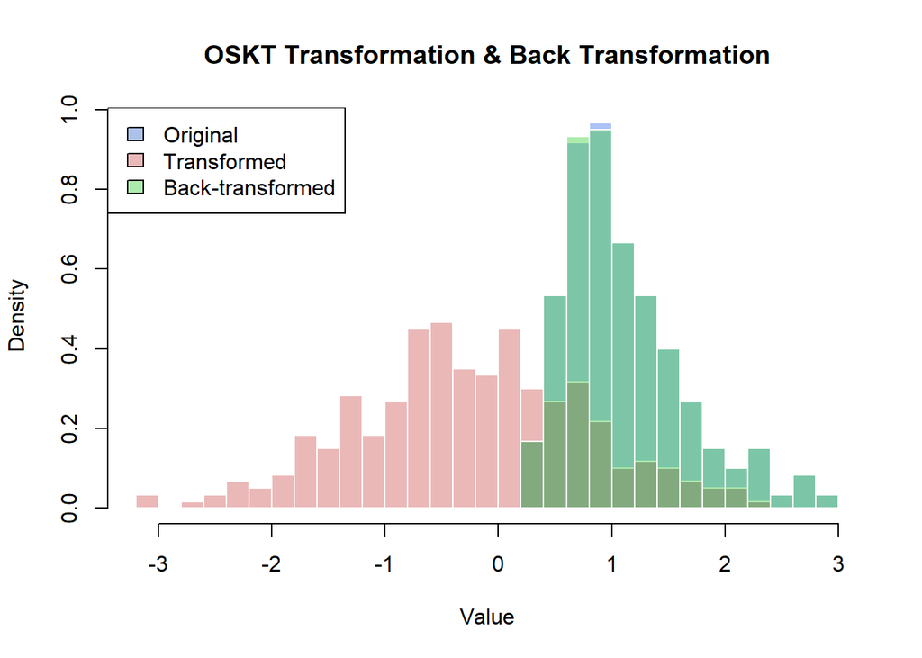

```r
breaks <- pretty(range(c(x_orig, x_transformed, x_recovered)), n = 30)
hist(x_orig, breaks = breaks, freq = FALSE, col = rgb(0.2, 0.4, 0.9, 0.4),
  border = "white", main="OSKT Transformation & Back Transformation", xlab="Value")
hist(x_transformed, breaks = breaks, freq = FALSE, col = rgb(0.8, 0.3, 0.3, 0.4),
  border = "white", add=TRUE)
hist(x_recovered, breaks = breaks, freq = FALSE, col = rgb(0.2,0.8,0.2,0.4),
  border = "white", add=TRUE)

legend("topleft", legend = c("Original","Transformed","Back-transformed"),
       fill = c(rgb(0.2,0.4,0.8,0.4), rgb(0.8,0.3,0.3,0.4), rgb(0.2,0.8,0.2,0.4)))
```

```r
(all.equal(x_orig, x_recovered, tolerance = 1e-6)) # Comparison to the originals with a tolerance
  [1] "Mean relative difference: 0.0006286436"
```

# 5 Back-transformation Diagnostics

In the code snippet below, the original values and the recovered values obtained via back-transformation are compared using various criteria. The difference between the original and recovered values is treated as the back-transformation error, and error-based performance metrics such as Mean Absolute Error (MAE), Maximum Absolute Error (MAXE), Mean Squared Error (MSE), and Root Mean Squared Error (RMSE) can be computed. In addition, for diagnostic analysis, the correlation coefficient between the original and recovered values, as well as the regression coefficient and goodness of fit measured by R-squared, can also be examined.

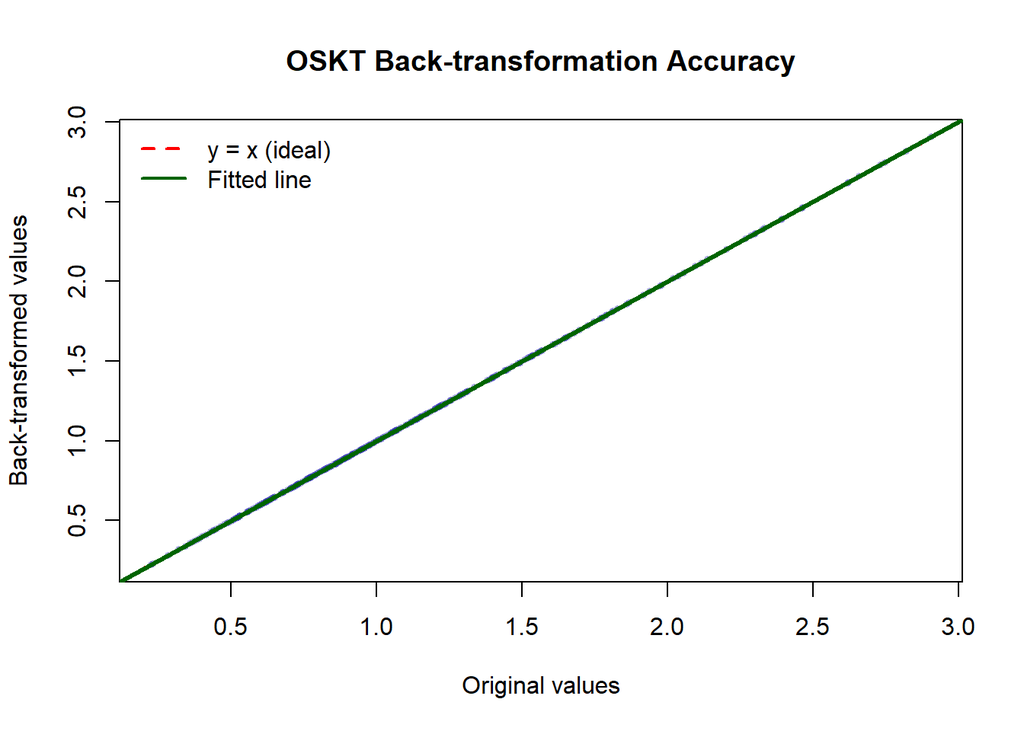

```r
ok <- is.finite(x_orig) & is.finite(x_recovered) # Remove any non-finite values

xo <- x_orig[ok]
xr <- x_recovered[ok]
err <- xr - xo #Error

# Performance metrics
MAE  <- mean(abs(err))
MAXE <- max(abs(err))
MSE  <- mean(err^2)
RMSE <- sqrt(MSE)

# Correlation and R^2
COR  <- cor(xo, xr)
R2   <- COR^2

# Linear fit (recovered ~ original)
fit <- lm(xr ~ xo)
slope     <- coef(fit)[2]
intercept <- coef(fit)[1]

# Summary table
back_stats <- data.frame(
  MSE = MSE, RMSE = RMSE, MAE = MAE, MaxError = MAXE,
  Correlation= COR, R2 = R2, Slope = slope, Intercept  = intercept)

round(t(back_stats), 8)
                       xo
  MSE          0.00000080
  RMSE         0.00089459
  MAE          0.00069680
  MaxError     0.00300090
  Correlation  1.00000000
  R2           1.00000000
  Slope        1.00167084
  Intercept   -0.00185199

# Regression line for diagnostic
plot(xo, xr,
     pch = 16, cex = 0.6, col = rgb(0.2, 0.2, 0.7, 0.4),
     xlab = "Original values", ylab = "Back-transformed values",
     main = "OSKT Back-transformation Accuracy")

abline(0, 1, col = "red", lwd = 2, lty = 3) # 1:1 reference line
abline(fit, col = "darkgreen", lwd = 3) # Fitted regression line

legend("topleft",
       legend = c("y = x (ideal)", "Fitted line"),
       col = c("red", "darkgreen"),
       lwd = 2, lty = c(2,1), bty = "n")
```

# 6 Comparison of Normality Methods

Below, a left-skewed variable with 300 observations is generated using the `ghdist` function from the `groupcompare` package. This data is then transformed using the Box-Cox (BC), Yeo-Johnson (YJ), and OSKT methods. The transformed values are subsequently tested for normality using the Shapiro–Wilk (SW) normality test, as well as the Cramer-von Misses (CVM), and Wang-Zu ZA tests available in the `osktnorm` package. In addition, the Pearson P statistic (PPM) is computed and used as a metric that evaluates the transformed values across the entire distribution, from the left tail to the right tail.

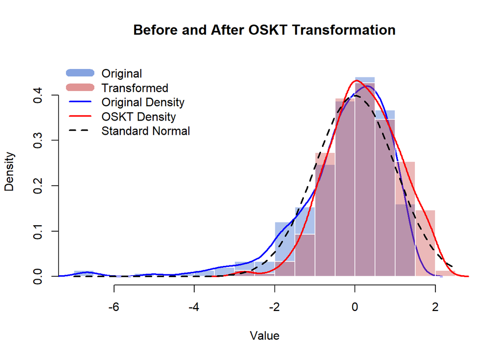

```r
# Generate left-skewed data
set.seed(12)
x_orig <- groupcompare::ghdist(n=300, A=0, B=1, g=-0.49, h=0)
x_transformed <- osktfast(x_orig)$transformed

breaks <- pretty(range(c(x_orig, x_transformed)), n = 25)
h_orig  <- hist(x_orig, breaks = breaks, plot = FALSE)
h_trans <- hist(x_transformed, breaks = breaks, plot = FALSE)

d_orig  <- density(x_orig); d_trans <- density(x_transformed)

ymax <- max(c(h_orig$density, h_trans$density, d_orig$y,d_trans$y, dnorm(0)))
hist(x_orig, breaks = breaks, freq = FALSE, ylim = c(0, ymax * 1.05),
     col = rgb(0.2, 0.4, 0.8, 0.4), border = "white",
     main = "Before and After OSKT Transformation", xlab = "Value")
lines(d_orig, col = "blue", lwd = 2)

hist(x_transformed, breaks = breaks, freq = FALSE,
     col = rgb(0.8, 0.3, 0.3, 0.4), border = "white", add = TRUE)
lines(d_trans, col = "red", lwd = 2)

curve(dnorm(x), add = TRUE, lwd = 2, lty = 2, col = "black") # Standard normal reference

legend("topleft",
   legend = c("Original", "Transformed", "Original Density", "OSKT Density", "Standard Normal"),
   col = c(rgb(0.2,0.4,0.8,0.6), rgb(0.8,0.3,0.3,0.6), "blue", "red", "black"),
   lwd = c(10, 10, 2, 2, 2), lty = c(1, 1, 1, 1, 2), bty = "n")
```

```r
# Normality tests with BC, YJ and OSKT
x_bc <- boxcox(x_orig, makepositive=TRUE)$transformed # Box-Cox transformation
x_yj <- yeojohnson(x_orig)$transformed  # Yeo-Johnson transformation
x_oskt <- osktfast(x_orig)$transformed # OSKT

# Normality tests and moments
get_stats <- function(x) {
  x <- x[is.finite(x)]
  c(
    Skew = mean((x - mean(x))^3) / sd(x)^3,
    Kurt = mean((x - mean(x))^4) / sd(x)^4 - 3,
    SW  = shapiro.test(x)$p.value,
    ZA  = zatest(x, nsim=100)$p.value,
    CVM = cvmtest(x)$p.value,
    PPM = unname(pearsonp(x)$statistic)
  )
}

# Normality results table
pval_table <- rbind(
  ORG  = get_stats(x_orig),
  BC  = get_stats(x_bc),
  YJ   = get_stats(x_yj),
  OSKT = get_stats(x_oskt)
)

pval_table <- as.data.frame(round(pval_table, 4))
pval_table
          Skew    Kurt     SW     ZA    CVM  PPM
  ORG  -1.8642  5.9759 0.0000 0.0099 0.0001 9.24
  BC   -0.2397 -0.5635 0.0047 0.0099 0.1550 0.82
  YJ   -0.0454 -0.3109 0.1257 0.0396 0.3866 0.71
  OSKT -0.2130  0.0118 0.0631 0.0099 0.9085 0.56
```

Upon examining the table above, it is observed that OSKT reduces kurtosis close to 0, whereas YJ is more effective in reducing skewness. However, according to the PPM statistic, the best performance is obtained by OSKT with a value of 0.56, indicating that the method attempts to correct the entire distribution, not just the tails. Based on the SW and CVM normality tests, both YJ and OSKT are successful in normalizing the data, but according to the ZA test, neither method performs adequately. In conclusion, considering the SW, CVM, and PPM results as well as the reduction in kurtosis, OSKT demonstrates better performance compared to the other methods evaluated.